# Untitled

MTBR - ModelThinkingBR

3/14/2020

[figure not shown]

# Por que investir?

Como esta sua situacao financeira?

Caso tenha uma reserva pode ser interessante pensar em investimentos

Diferenca de poupar e investir

**Poupar** é acumular valores no presente para utilizá-los no futuro, o que geralmente envolve mudança de hábitos, pois requer uma redução nos gastos pessoais e familiares.

**Investir** é empregar o dinheiro poupado em aplicações que rendam juros ou outra forma de remuneração ou correção.

Nao existe investimento sem risco

Importancia da segurança financeira

# Montagem da carteira

Após definir a quantidade a ser investida é hora de divessificar a carteira

“Talvez você já tenha ouvido falar essa frase alguma vez na sua vida. Não colocar todos os ovos na mesma cesta significa que você deve diversificar o seu investimento.”

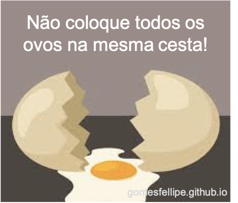

Por que diversificar?

proteger os rendimentos diminuindo os riscos

Como dividir?

Para ajudar a dividir a carteira de investimentos com utilizaremos a chamada [regra (ou lei) dos 80](https://www.btgpactualdigital.com/blog/coluna-gustavo-cerbasi/defina-sua-estrategia-entre-renda-fixa-ou-variavel).

A estratégia é a seguinte: subtraia da sua idade o número 80. O resultado dessa conta vai indicar o percentual a ser investido em [renda variável](https://pt.wikipedia.org/wiki/Renda_vari%C3%A1vel)!

Por exemplo, no meu caso: Tenho 26 anos, portanto $80-26 = 54\%$ deverá ser investido em renda variável. Aos 53 anos esse percentual vai cairá para a metade, $27\%$.

A idéias principal por trás desta regra que é que a cada ano que passa, 1% do montante da renda variável deva ser direcionado para a [renda fixa](https://pt.wikipedia.org/wiki/Renda_fixa).

Testar a função `montagem()` para diverentes cenários:

```r
source("montagem.R")
source("moeda_real.R")
```

* Entrada de R$20.000,00 ←

```r
montagem(entrada = 20000, idade = 26)
```

```
## • Entrada: R$R\$20.000,00
##   └─ Renda fixa:     R\$9.200,00
##   └─ Renda variavel: R\$10.800,00
##        (Acao + Cryptomoeda):
##        R\$9.720,00 + R\$1.080,00
```

- R$ 10.000,00 em acoes

```r
montagem(variavel = 10000, idade = 26)
```

```
## • Entrada: R$R\$18.518,52
##   └─ Renda fixa:     R\$8.518,52
##   └─ Renda variavel: R\$10.000,00
##        (Acao + Cryptomoeda):
##        R\$9.000,00 + R\$1.000,00
```

- R$5.000,00 em tesouro direto

```r
montagem(fixa = 5000, idade = 26)
```

```
## • Entrada: R$R\$10.869,57
##   └─ Renda fixa:     R\$5.000,00
##   └─ Renda variavel: R\$5.869,57
##        (Acao + Cryptomoeda):
##        R\$5.282,61 + R\$586,96
```

- Montagem de R$20.000,00 aos 53 anos

```r
montagem(entrada = 20000, idade = 53)
```

```
## • Entrada: R$R\$20.000,00
##   └─ Renda fixa:     R\$14.600,00
##   └─ Renda variavel: R\$5.400,00
##        (Acao + Cryptomoeda):
##        R\$4.860,00 + R\$540,00
```

- Entrada: R$20.000,00
- Renda fixa: R$9.200,00
- Renda Variavel (Acoes): R$9.720,00
- Renda Variavel (Crypt): R$1.080,00

## Renda fixa

Para avaliar nossa escolha utilizaremos o simulador disponivel no site https://verios.com.br/ neste [link](https://simulador-tesouro-direto.verios.com.br/):

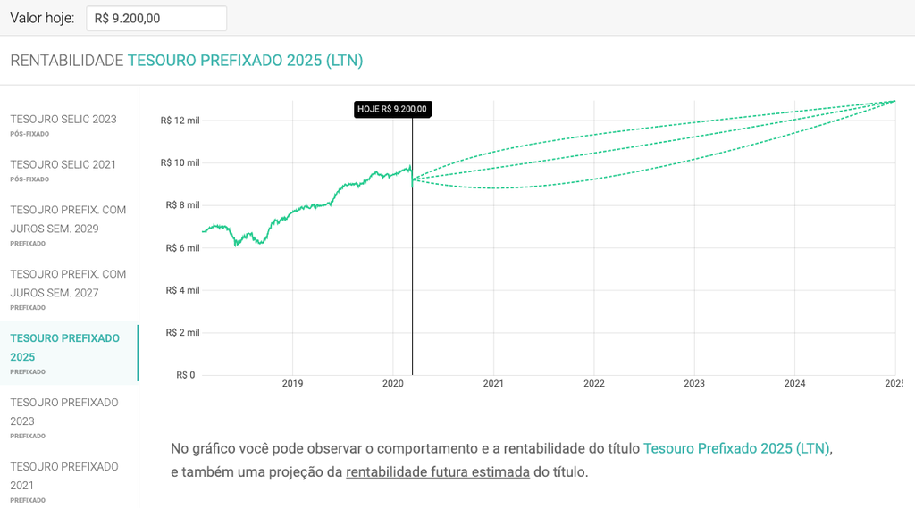

Fonte: https://simulador-tesouro-direto.verios.com.br/

## Renda variável

Para este exemplo escolhe 2 ações 1 crypto moeda:

```r
# portifolio = c("PETR4.SA","FIBR3.SA", "BTC-USD")
portifolio = c("TUPY3.SA","ELET3.SA", "BTC-USD")
```

### Importar

Faremos a aquisição das série históricas dos dados com o pacote `quantmod`, veja:

```r
# stocks <-map_df(portifolio, ~tq_get(.x, get = "stock.prices", from = " 2018-01-01"))
# saveRDS(stocks, "stocks.rds")
stocks <- readRDS("stocks.rds")
```

### Arrumar e transformar (tsibble)

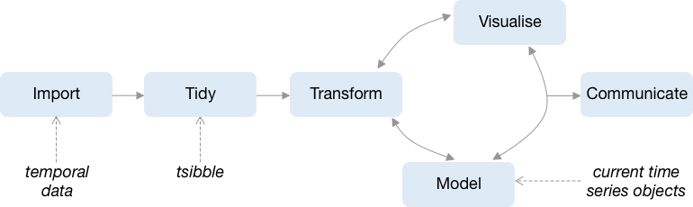

Converter para tibble, preencher espaçoes em branco (finais de semana) como valor anterior

```r
tbl_stocks <- stocks %>% as_tsibble(key = symbol, index = date)
```

### Transformar

```r
tbl_stocks <-
  tbl_stocks %>%
  fill_gaps() %>%
  tidyr::fill(c(open, high, low, close, volume, adjusted),.direction = "down")
```

### Visualizar

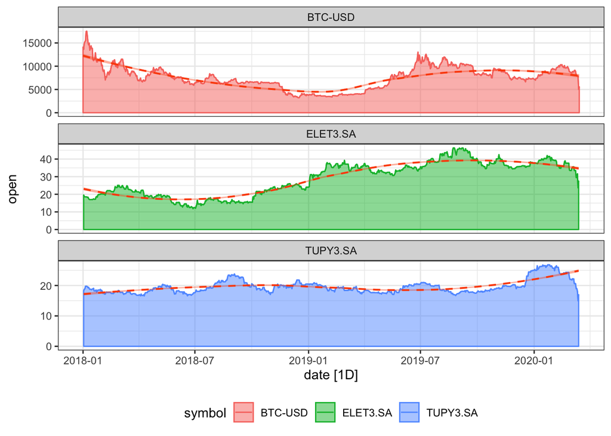

```r
# series
d2 <-
  tbl_stocks %>%
  group_by(symbol) %>%
  summarise(y = mean(close))

autoplot(tbl_stocks)+
  facet_wrap(~symbol, scales = "free_y", ncol = 1)+
  theme(legend.position = "bottom") +
  geom_area(aes(color = symbol, fill = symbol),
            alpha = 0.5, position = position_dodge(0.8)) +
  stat_smooth(color = "#FC4E07", fill = "#FC4E07", linetype = 2, size = 0.7,method = "loess")
```

sazonalidade

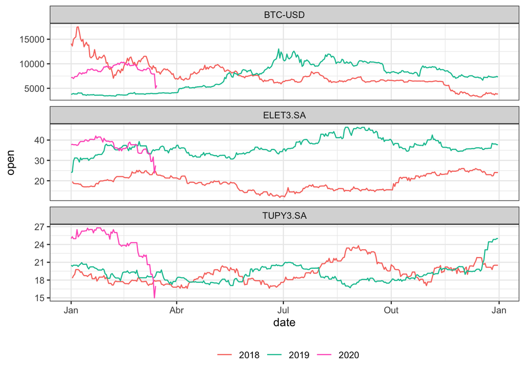

```r
gg_season(tbl_stocks)+
  facet_wrap(~symbol, scales = "free_y", ncol = 1)+
  theme(legend.position = "bottom")
```

Correlacoes

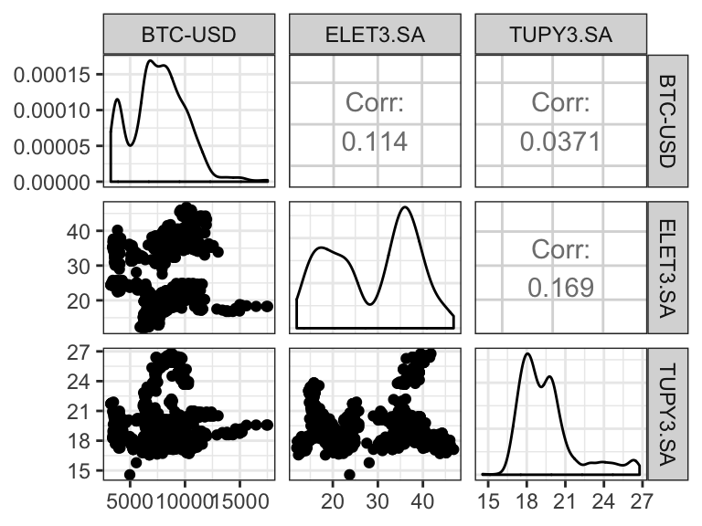

```r
tbl_stocks %>%
  as_tibble() %>%
  select(symbol, date, close) %>%
  spread(key = symbol, value = close) %>%
  GGally::ggpairs(columns = 2:4)
```

Forecast com h2o

https://www.business-science.io/code-tools/2017/10/28/demo_week_h2o.html

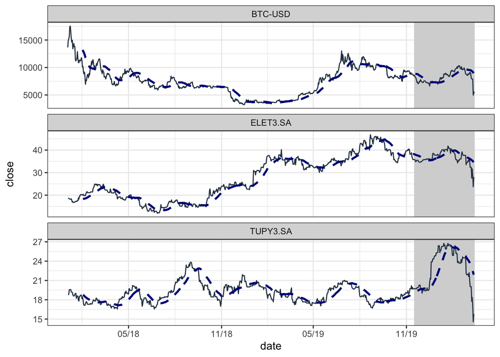

```r
data_split1 <- Sys.Date()-30*4
data_split2 <- Sys.Date()-30*1

# Plot Beer Sales with train, validation, and test sets shown
tbl_stocks %>%
  ggplot(aes(date, close)) +
  geom_rect(xmin = as.numeric(data_split1), xmax = as.numeric(data_split2),
            ymin = 0, ymax = Inf, alpha = 0.02, fill = "#C1C3E3") +
  geom_rect(xmin = as.numeric(data_split2), xmax = as.numeric(Sys.Date()),
            ymin = 0, ymax = Inf, alpha = 0.02, fill = "#E8D3D3") +
  geom_line(col = palette_light()[1]) +
  geom_ma(ma_fun = SMA, n = 30, size = 1) +
  scale_x_date(date_breaks = "6 month", date_labels = "%m/%y") +
  facet_wrap(~symbol, ncol = 1, scales = "free_y")
```

```r
tbl_stocks_automl <-
  tbl_stocks %>%
  as_tibble() %>%
  transmute(symbol, day = lubridate::day(date),
            month = lubridate::month(date),
            year = lubridate::year(date),
            close = log(close),
            wday = lubridate::wday(date),
            diff = close - lag(close),
            diff2 = diff - lag(diff),
            date) %>%
  slice(-1) %>%
  group_by(symbol) %>%
  nest() %>%
  mutate(train_h2o = map(data, ~.x %>%
                           filter(date <= data_split1) %>%
                           select(-date) %>% as.h2o()),
         valid_h2o = map(data, ~.x %>%
                           filter(date > data_split1 & date <= data_split2) %>%
                           select(-date) %>% as.h2o()) ,
         test_h2o  = map(data, ~.x %>%
                           filter(date > data_split2) %>%
                           select(-date) %>% as.h2o()),
         automl_models_h2o = pmap(list(train_h2o = train_h2o,
                                       valid_h2o = valid_h2o,
                                       test_h2o = test_h2o),
                                  function(train_h2o, valid_h2o, test_h2o){
                                    automl_models_h2o <- h2o.automl(
                                      x = setdiff(names(train_h2o), "close"),
                                      y = "close",
                                      training_frame = train_h2o,
                                      validation_frame = valid_h2o,
                                      leaderboard_frame = test_h2o,
                                      max_runtime_secs = 60*10,
                                      verbosity = NULL,
                                      stopping_metric = "deviance")
                                  }),
         automl_leader = map(automl_models_h2o, ~ .x@leader) ,
         pred_h2o =  map2(automl_leader, test_h2o, ~h2o.predict(.x, newdata = .y)),
         error_tbl = map2(data, pred_h2o,
                          ~.x %>% filter(date > data_split2) %>%
                            add_column(pred = .y %>% as_tibble() %>% pull(predict)) %>%
                            rename(actual = close) %>%
                            mutate(error     = actual - pred,
                                   error_pct = error / actual) )

  )
saveRDS(tbl_stocks_automl, "tbl_stocks_automl.rds")
```

```r
tbl_stocks_automl <- readRDS("tbl_stocks_automl.rds")
```

Avaliar performance dos modelos:

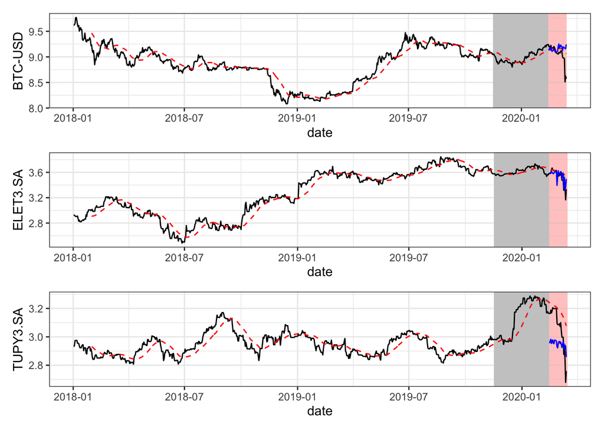

```r
# map2(tbl_stocks_automl$automl_leader, tbl_stocks_automl$test_h2o,
#      ~ h2o.performance(.x, newdata = .y))

pmap(list(.x = tbl_stocks_automl$data,
          .y = tbl_stocks_automl$error_tbl,
          .z = tbl_stocks_automl$symbol),
     function(.x, .y, .z){
       .x %>%
         ggplot(aes(x = date, y = close)) +
         geom_rect(xmin = as.numeric(data_split1),
                   xmax = as.numeric(data_split2),
                   ymin = 0, ymax = Inf, alpha = 0.015,
                   fill = "#C1C3E3") +
         geom_rect(xmin = as.numeric(data_split2),
                   xmax = as.numeric(Sys.Date()),
                   ymin = 0, ymax = Inf, alpha = 0.015,
                   fill = "#E8D3D3") +
         geom_line(aes(y = close), size = 0.5) +
         geom_ma(n = 30, color = "red") +
         geom_line(aes(y = pred), color = "blue", size = 0.5, data = .y)+
         labs(y = .z)

     }
) %>% { .[[1]] / .[[2]] / .[[3]] }
```

Parece interessante, vamos às compras!

# Comprando acoes

após todo o estudo para a elaboracao da carteira chegou a hora das compras.

Suponha que tivessemos realizado nossas compra no fechamento do dia 09/01/2020, quando as cotações eram as seguintes:

```r
tbl_stocks %>%
  filter(date == "2020-01-09") %>%
  mutate(close = cell_spec(moeda_real(close), "html",
                           color = "blue")) %>%
  mutate_at(c(3:5, 8), ~moeda_real(.x)) %>%
  kable2()
```

| symbol | date | open | high | low | close | volume | adjusted |
| --- | --- | --- | --- | --- | --- | --- | --- |
| BTC-USD | 2020-01-09 | R$8.082,30 | R$8.082,30 | R$7.842,40 | R$7.879,07 | 24045990465 | R$7.879,07 |
| ELET3.SA | 2020-01-09 | R$ 39,31 | R$ 39,72 | R$ 39,08 | R$ 39,35 | 4357400 | R$ 39,35 |
| TUPY3.SA | 2020-01-09 | R$ 25,84 | R$ 26,05 | R$ 25,60 | R$ 26,05 | 465400 | R$ 26,05 |

```r
cot_inicio = c(elet = 39.35, tupy = 26.05)
qtd_inicio = c(elet = 190, tupy = 90)
```

Neste dia a cotação para ELET3 era R$39,35 e TUPY3 era R$26,05 e suponha que tenhamos comprado 190 lotes fracionarios de ELET3 e 90 de TUPY, totalizando R$9.821,00 (próximo ao que avíamos planejado no inicio do estudo)

Note que o valor do Bitcoin está em dólares, para obter o valor em reai daquele dia vamos utilizar a API do Mercado Bitcoin:

```r
url <- glue::glue("https://www.mercadobitcoin.net/api/BTC/day-summary/2020/01/09/")
safe_fromJSON <- safely(fromJSON, as.numeric(NA))
consulta <- safe_fromJSON(url)$result %>% as_tibble()

consulta %>%
  select(-date) %>%
  mutate_all(~moeda_real(.x)) %>%
  mutate(closing = cell_spec(closing, "html", color = "blue")) %>%
  kable2()
```

| opening | closing | lowest | highest | volume | quantity | amount | avg_price |
| --- | --- | --- | --- | --- | --- | --- | --- |
| R$32.580 | R$32.243,90 | R$32.000 | R$32.780,40 | R$5.636.666,00 | R$174,37 | R$4.582 | R$32.326,16 |

O preço de fechamento foi de R$32.243,90, suponhamos que tenha sido este o valor pago no dia. (Parece que neste dia o dolar estava em torno de R$4,09)

```r
cot_inicio[3] <- consulta$closing
qtd_inicio[3] <- 0.032
```

Portanto, ao valor de R$32.243,90 compramos 0.032 Bitcoin totalizano 1031.8048 completando nossa carteira.

## Tabela financeira

Semelhante a uma planilha financeira, criaremos uma tabela financeira automatizada que receberá como input os valores da montagem e calculará automaticamente os valores do desmontagem no tempo atual utilizando dados de apis abertas.

Primeiro valos obter as cotacoes mais recentes das cotações das acoes que compramos na bolsa:

Obter dados da alphavantager https://www.business-science.io/code-tools/2017/09/03/alphavantager-0-1-0.html

```r
av_api_key(key)

consulta_acoes <- map_df(portifolio[1:2], ~{
  # cat(paste0("Coletar: ", .x, "\n"))
  av_get(symbol = .x,
         av_fun = "TIME_SERIES_INTRADAY",
         interval = "1min",  # "1min", "5min", "15min", "30min" ou "60min"
         outputsize = "compact") %>%  # "full"
    bind_cols(stock = rep(.x, nrow(.)))
}
)
```

```r
consulta_acoes %>%
  as_tsibble(key = stock, index = timestamp) %>%
  autoplot()+
  facet_wrap(~stock, scales = "free_y", ncol = 1)+
  theme(legend.position = "bottom")
```

[output not shown]

Coletar a cotação do Bitcoin (em reais) mais recente:

[Api do mercado bitcoin](https://www.mercadobitcoin.com.br/api-doc/?)

```r
coin <- "BTC"
method <- "ticker"
url <- glue::glue("https://www.mercadobitcoin.net/api/{coin}/{method}/")

safe_fromJSON <- safely(fromJSON, as.numeric(NA))
consulta_bitcoin <-
  safe_fromJSON(url)$result$ticker %>%
  as_tibble() %>%
  transmute(timestamp = lubridate::ymd_hms(as.POSIXct(date, origin="1970-01-01")),
            open, high, low, close = sell, volume = NA, stock = "BTC.BR") %>%
  mutate_at(c('open', 'high', 'low', 'close'), ~as.numeric(.x))
```

Combinar e padronizar as requisições:

```r
consulta_atual <-
  bind_rows(
    consulta_acoes %>%
      group_by(stock) %>%
      filter(timestamp == last(timestamp))
    ,
    consulta_bitcoin
  )

consulta_atual  %>%
  mutate_at(2:4, ~moeda_real(.x)) %>%
  mutate(close = cell_spec(moeda_real(close), "html", color = "blue")) %>%
  kable2()
```

| timestamp | open | high | low | close | volume | stock |
| --- | --- | --- | --- | --- | --- | --- |
| 2020-03-13 15:54:00 | R$15,63 | R$15,63 | R$15,63 | R$15,63 | 85 | TUPY3.SA |
| 2020-03-13 15:54:00 | R$27,76 | R$27,90 | R$27,65 | R$27,90 | 3910 | ELET3.SA |
| 2020-03-15 04:40:43 | R$28.063,53 | R$29.000,00 | R$26.500,00 | R$27.895,71 | NA | BTC.BR |

```r
# Tabela resultado
financas <-
  tibble(
    ativo = portifolio,
    # inicio
    cot_inicio = cot_inicio,
    qtd_inicio = qtd_inicio,
    vol_inicio = cot_inicio * qtd_inicio,
    # Desinicio / Atual
    cot_atual = consulta_atual$close,
    qtd_atual = qtd_inicio,
    vol_atual = cot_atual * qtd_atual,
    # Resultado
    ganho_perda = vol_atual - vol_inicio,
    resultado_bruto = ganho_perda / vol_inicio * 100
  )
```

```r
porcentagem <- function(x){paste0(round(x,2), "%")}

# Exibicao
financas  %>%
  mutate(
    cot_inicio = moeda_real(cot_inicio),
    cot_atual = moeda_real(cot_atual),
    vol_inicio = moeda_real(vol_inicio),
    vol_atual = moeda_real(vol_atual),
    qtd_inicio = round(qtd_inicio,4),
    qtd_atual = round(qtd_atual,4),
    # vol_atual = color_bar("lightgreen")(round(vol_atual, 2)),
    # vol_inicio = color_bar("lightgreen")(round(vol_inicio, 2)),
    `Vender?` = ifelse(ganho_perda > 0,"\u2713", "\u2718") ,
    ganho_perda = cell_spec(moeda_real(ganho_perda), "html",
                            color = ifelse(ganho_perda > 0, "green", "red")),
    resultado_bruto = cell_spec(porcentagem(resultado_bruto), "html",
                                color = ifelse(resultado_bruto > 0, "green", "red"))) %>%
  kable(format = "html", escape = F) %>%
  kable_styling(c("striped", "bordered", "hover", "responsive"), full_width = F) %>%
  add_header_above(c(" ", "Montagem" = 3, "Desmontagem / Atual" = 3, "Resultado" = 3))
```

[output not shown]

# Bot Telegram

```r
# Definir bot
bot <- TGBot$new(token = bot_token('fgstockbot'))

# Conectar ao R
bot$set_default_chat_id(bot$getUpdates()$message$chat$id[1])
```

```r
acompanhar_bitcoin <- function(frequencia = 60) {
  # load("historico.RData")

  # loop infinito
  while(
    !Sys.time() > lubridate::ymd_hm("2020-03-14 10:00") & # abertura
    Sys.time() < lubridate::ymd_hm(paste0(Sys.Date(), " 17:00")) # fechamento
  ) {

    # Requisicao das cotacoes atuais
    request <- map(ativos, ~{
      cat(paste0("Coletar: ", .x, "\n"))
      av_get(symbol = .x,
             av_fun = "TIME_SERIES_INTRADAY",
             interval = "1min",  # "1min", "5min", "15min", "30min" ou "60min"
             outputsize = "compact") # "full"
    }
    ) %>% `names<-`(ativos)

    # verifica se a API retornou uma lista
    if(is.list(request)) {

      financas <-
        tibble(
          ativo = paste0(ativos, ".SA"),
          # inicio
          cot_inicio = cot_inicio,
          qtd_inicio = qtd_inicio,
          vol_inicio = cot_inicio * qtd_inicio,
          # Desinicio / Atual
          cot_atual = map_dbl(request, ~last(.x$close)),
          qtd_atual = qtd_inicio,
          vol_atual = cot_atual * qtd_atual,
          # Resultado
          ganho_perda = vol_atual - vol_inicio,
          resultado_bruto = ganho_perda / vol_inicio * 100
        )

      # Exibicao
      tabela <-
        financas  %>%
        mutate(
          cot_inicio = moeda(cot_inicio),
          cot_atual = moeda(cot_atual),
          vol_inicio = moeda(vol_inicio),
          vol_atual = moeda(vol_atual),
          qtd_inicio = round(qtd_inicio,4),
          qtd_atual = round(qtd_atual,4),
          # vol_atual = color_bar("lightgreen")(round(vol_atual, 2)),
          # vol_inicio = color_bar("lightgreen")(round(vol_inicio, 2)),
          `Vender?` = ifelse(ganho_perda > 0,"\u2713", "\u2718") ,
          ganho_perda = cell_spec(moeda(ganho_perda), "html",
                                  color = ifelse(ganho_perda > 0, "green", "red")),
          resultado_bruto = cell_spec(porcentagem(resultado_bruto), "html",
                                      color = ifelse(resultado_bruto > 0, "green", "red"))) %>%
        kable(format = "html", escape = F) %>%
        kable_styling(c("striped", "bordered", "hover", "responsive"), full_width = F) %>%
        add_header_above(c(" ", "Montagem" = 3, "Desmontagem / Atual" = 3, "Resultado" = 3))

      save_kable(tabela, file = "table.png", self_contained = F)


      cat("Preparar para enviar menssagem..\n")
      bot$sendPhoto('table.png', caption = paste0("Tabela de resultados (",Sys.time(),")"))
      cat("Menssagem enviada!\n")
    }

    cat(paste0("Aguarde ", frequencia, " segundos..\n"))
    Sys.sleep(frequencia/2)
    cat(paste0("Aguarde ", round(frequencia/2,1), " segundos..\n"))
    Sys.sleep(frequencia/2)

  }
}

acompanhar_bitcoin()
```

# Referencias

- https://www.investidor.gov.br/menu/primeiros_passos/antes_investir/antes_investir.html
- https://www.btgpactualdigital.com/blog/investimentos/diversificacao-de-investimentos
- https://www.btgpactualdigital.com/blog/coluna-gustavo-cerbasi/defina-sua-estrategia-entre-renda-fixa-ou-variavel
- https://blog.earo.me/2018/12/20/reintro-tsibble/
- https://www.tradingcomdados.com/post/2017/07/09/estudo-de-correla%C3%A7%C3%A3o-entre-a%C3%A7%C3%B5es-da-bolsa-de-valores-de-s%C3%A3o-paulo
- https://www.business-science.io/code-tools/2017/10/28/demo_week_h2o.html